# PART III

Enmin Li

2022/4/26

## PART III-A

```r
library(tidyverse)
library(caret)
```

```r
library(coefplot)
```

```r
df_all <- readr::read_csv("final_project_train.csv", col_names = TRUE)
df_all %>% glimpse()
```

```
## Rows: 677
## Columns: 38
## $ rowid    <dbl> 1, 3, 4, 5, 8, 9, 11, 14, 15, 16, 17, 18, 19, 22, 24, 25, 27,~
## $ region   <chr> "XX", "XX", "XX", "XX", "XX", "XX", "XX", "XX", "XX", "XX", "~
## $ customer <chr> "B", "B", "B", "B", "B", "B", "B", "B", "B", "B", "B", "B", "~
## $ xb_01    <dbl> 4.000000, 1.000000, 2.000000, 2.520000, 2.548387, 3.071429, 3~
## $ xb_02    <dbl> 4, 1, 2, 11, 6, 6, 10, 12, 9, 10, 8, 10, 10, 8, 6, 10, 13, 10~
## $ xb_03    <dbl> 4, 1, 2, -6, -1, 1, -4, -4, -2, -4, -2, -2, -2, -4, 1, -4, -3~
## $ xn_01    <dbl> 3.0000000, 2.0000000, 2.0000000, 1.5333333, 0.8387097, 1.8571~
## $ xn_02    <dbl> 3, 2, 4, 9, 3, 8, 6, 10, 10, 4, 6, 8, 9, 5, 7, 12, 12, 6, 6, ~
## $ xn_03    <dbl> 3, 2, 0, -3, -4, -2, -5, -6, -3, -5, -3, -6, -4, -3, 0, -5, -~
## $ xa_01    <dbl> 12.000000, 3.000000, 9.000000, 7.080000, 6.451613, 6.857143, ~
## $ xa_02    <dbl> 12, 3, 9, 29, 17, 18, 24, 27, 20, 19, 15, 24, 24, 15, 14, 26,~
## $ xa_03    <dbl> 12, 3, 9, -7, -2, 2, -9, -5, -3, -3, -1, 1, -2, -3, 3, -4, -5~
## $ xb_04    <dbl> 1.3333333, 1.0000000, 1.0000000, 0.8950476, 1.2247312, 1.1857~
```

[output cut: 25 more lines]

The binary output, `outcome`, has two levels (unique values). However, because `outcome` is a character data type, the information about the unique values is not “known” by the object. For example, the `summary()` function simply says `outcome` is a character.

```r
df_all %>%
  select(outcome) %>%
  summary()
```

```
##    outcome
##  Length:677
##  Class :character
##  Mode  :character
```

There are multiple ways to check the unique values of a variable within the `tidyverse`. I recommend reviewing the Introduction to R tutorials which shows one of my favorite simple `tidyverse` functions, `count()`. This function not only identifies the unique values of a variable but also counts the number of rows associated with each unique value. In this example RMarkdown however, I will show the unique values with the `distinct()` function, which identifies the distinct values:

```r
df_all %>%
  distinct(outcome)
```

```
## # A tibble: 2 x 1
##   outcome
##   <chr>
## 1 non_event
## 2 event
```

Part iiiA) of the project requires that you fit generalized linear models (GLMs) to classify the event. As discussed in the beginning of the semester, these models are not trying to classify the event directly. Instead, they are trying to predict the event probability. You can fit a non-Bayesian GLM using the `glm()` function from base R. When working with `glm()`, I find it easier to have the event of interested converted to the 0/1 encoding instead of the character string names. The code chunk below creates the data set associated with Part iiiA) of the project by selecting the categorical inputs, `region` and `customer`, the sentiment derived continuous features, and the 0/1 encoded binary outcome, `y` which is calculated using `ifelse()`.

```r
dfiiiA <- df_all %>%
  mutate(y = ifelse(outcome == 'event', 1, 0)) %>%
  select(region, customer, starts_with('x'), y)

dfiiiA %>% glimpse()
```

```
## Rows: 677
## Columns: 36
## $ region   <chr> "XX", "XX", "XX", "XX", "XX", "XX", "XX", "XX", "XX", "XX", "~
## $ customer <chr> "B", "B", "B", "B", "B", "B", "B", "B", "B", "B", "B", "B", "~
## $ xb_01    <dbl> 4.000000, 1.000000, 2.000000, 2.520000, 2.548387, 3.071429, 3~
## $ xb_02    <dbl> 4, 1, 2, 11, 6, 6, 10, 12, 9, 10, 8, 10, 10, 8, 6, 10, 13, 10~
## $ xb_03    <dbl> 4, 1, 2, -6, -1, 1, -4, -4, -2, -4, -2, -2, -2, -4, 1, -4, -3~
## $ xn_01    <dbl> 3.0000000, 2.0000000, 2.0000000, 1.5333333, 0.8387097, 1.8571~
## $ xn_02    <dbl> 3, 2, 4, 9, 3, 8, 6, 10, 10, 4, 6, 8, 9, 5, 7, 12, 12, 6, 6, ~
## $ xn_03    <dbl> 3, 2, 0, -3, -4, -2, -5, -6, -3, -5, -3, -6, -4, -3, 0, -5, -~
## $ xa_01    <dbl> 12.000000, 3.000000, 9.000000, 7.080000, 6.451613, 6.857143, ~
## $ xa_02    <dbl> 12, 3, 9, 29, 17, 18, 24, 27, 20, 19, 15, 24, 24, 15, 14, 26,~
## $ xa_03    <dbl> 12, 3, 9, -7, -2, 2, -9, -5, -3, -3, -1, 1, -2, -3, 3, -4, -5~
## $ xb_04    <dbl> 1.3333333, 1.0000000, 1.0000000, 0.8950476, 1.2247312, 1.1857~
## $ xb_05    <dbl> 1.3333333, 1.0000000, 1.0000000, -2.0000000, -0.5000000, 0.00~
```

[output cut: 23 more lines]

Part iiiD) of the project requires that you train and assess binary classifiers via resampling. The `caret` and `tidymodels` packages can be used to manage the resampling, tuning, and evaluation of the models. These two packages prefer to have the categorical output as a factor (R’s data type for a categorical variable) with the first level associated with the event of interest. The code chunk below converts `outcome` to a factor and forces the level ordering in the correct format. The inputs and `outcome` are then selected to produce the data associated with Part iiiD) of the project.

```r
dfiiiD <- df_all %>%
  mutate(outcome = factor(outcome,
                          levels = c("event", "non_event"))) %>%
  select(region, customer, starts_with('x'), outcome)

dfiiiD %>% glimpse()
```

```
## Rows: 677
## Columns: 36
## $ region   <chr> "XX", "XX", "XX", "XX", "XX", "XX", "XX", "XX", "XX", "XX", "~
## $ customer <chr> "B", "B", "B", "B", "B", "B", "B", "B", "B", "B", "B", "B", "~
## $ xb_01    <dbl> 4.000000, 1.000000, 2.000000, 2.520000, 2.548387, 3.071429, 3~
## $ xb_02    <dbl> 4, 1, 2, 11, 6, 6, 10, 12, 9, 10, 8, 10, 10, 8, 6, 10, 13, 10~
## $ xb_03    <dbl> 4, 1, 2, -6, -1, 1, -4, -4, -2, -4, -2, -2, -2, -4, 1, -4, -3~
## $ xn_01    <dbl> 3.0000000, 2.0000000, 2.0000000, 1.5333333, 0.8387097, 1.8571~
## $ xn_02    <dbl> 3, 2, 4, 9, 3, 8, 6, 10, 10, 4, 6, 8, 9, 5, 7, 12, 12, 6, 6, ~
## $ xn_03    <dbl> 3, 2, 0, -3, -4, -2, -5, -6, -3, -5, -3, -6, -4, -3, 0, -5, -~
## $ xa_01    <dbl> 12.000000, 3.000000, 9.000000, 7.080000, 6.451613, 6.857143, ~
## $ xa_02    <dbl> 12, 3, 9, 29, 17, 18, 24, 27, 20, 19, 15, 24, 24, 15, 14, 26,~
## $ xa_03    <dbl> 12, 3, 9, -7, -2, 2, -9, -5, -3, -3, -1, 1, -2, -3, 3, -4, -5~
## $ xb_04    <dbl> 1.3333333, 1.0000000, 1.0000000, 0.8950476, 1.2247312, 1.1857~
## $ xb_05    <dbl> 1.3333333, 1.0000000, 1.0000000, -2.0000000, -0.5000000, 0.00~
```

[output cut: 23 more lines]

If you look closely at the above print out, you will see that the `outcome` variable is a `fct` or factor data type. The object now “knows” all unique values associated with the variable. The `summary()` function now summarizes the counts for each unique value, as shown below:

```r
dfiiiD %>%
  select(outcome) %>%
  summary()
```

```
##       outcome
##  event    :127
##  non_event:550
```

Alternatively, we can call the `levels()` function to display the levels (unique values) of the factor variable:

```r
levels(dfiiiD$outcome )
```

```
## [1] "event"     "non_event"
```

Which could have been accomplished using “tidy” approaches as:

```r
dfiiiD %>% pull(outcome) %>% levels()
```

```
## [1] "event"     "non_event"
```

• Categorical variables only – linear

```r
set.seed(2001)
dfiiiD <- df_all %>%
  mutate(outcome = factor(outcome,
                          levels = c("event", "non_event"))) %>%
  select(region, customer, outcome)

ctrl_roc <- trainControl(method ='cv', number = 5,
                             summaryFunction = twoClassSummary,
                             classProbs = TRUE,
                             savePredictions = TRUE)

fit_glm_mod1 <- train( outcome ~ ., data = dfiiiD,
                        method = 'glm',
                        metric = "ROC",
                        preProcess = c("center", "scale"),
                        trControl = ctrl_roc)
```

• Continuous variables only – linear additive

```r
set.seed(2001)
dfiiiD <- df_all %>%
  mutate(outcome = factor(outcome,
                          levels = c("event", "non_event"))) %>%
  select(starts_with('x'), outcome)

ctrl_roc <- trainControl(method ='cv', number = 5,
                             summaryFunction = twoClassSummary,
                             classProbs = TRUE,
                             savePredictions = TRUE)

fit_glm_mod2 <- train( outcome ~ ., data = dfiiiD,
                        method = 'glm',
                        metric = "ROC",
                        preProcess = c("center", "scale"),
                        trControl = ctrl_roc)
```

• All categorical and continuous variables – linear additive

```r
set.seed(2001)
dfiiiD <- df_all %>%
  mutate(outcome = factor(outcome,
                          levels = c("event", "non_event"))) %>%
  select(region, customer, starts_with('x'),outcome)

ctrl_roc <- trainControl(method ='cv', number = 5,
                             summaryFunction = twoClassSummary,
                             classProbs = TRUE,
                             savePredictions = TRUE)

fit_glm_mod3 <- train( outcome ~ ., data = dfiiiD,
                        method = 'glm',
                        metric = "ROC",
                        preProcess = c("center", "scale"),
                        trControl = ctrl_roc)
```

```r
set.seed(2001)
dfiiiD <- df_all %>%
  mutate(outcome = factor(outcome,
                          levels = c("event", "non_event"))) %>%
  select(region,starts_with('x'),outcome)

ctrl_roc <- trainControl(method ='cv', number = 5,
                             summaryFunction = twoClassSummary,
                             classProbs = TRUE,
                             savePredictions = TRUE)

fit_glm_mod4 <- train( outcome ~ ., data = dfiiiD,
                        method = 'glm',
                        metric = "ROC",
                        preProcess = c("center", "scale"),
                        trControl = ctrl_roc)
```

```r
set.seed(2001)
dfiiiD <- df_all %>%
  mutate(outcome = factor(outcome,
                          levels = c("event", "non_event"))) %>%
  select(customer, starts_with('x'),outcome)

ctrl_roc <- trainControl(method ='cv', number = 5,
                             summaryFunction = twoClassSummary,
                             classProbs = TRUE,
                             savePredictions = TRUE)

fit_glm_mod5 <- train( outcome ~ ., data = dfiiiD,
                        method = 'glm',
                        metric = "ROC",
                        preProcess = c("center", "scale"),
                        trControl = ctrl_roc)
```

```r
set.seed(2001)
dfiiiD <- df_all %>%
  mutate(outcome = factor(outcome,
                          levels = c("event", "non_event"))) %>%
  select(starts_with('xa'),outcome)

ctrl_roc <- trainControl(method ='cv', number = 5,
                             summaryFunction = twoClassSummary,
                             classProbs = TRUE,
                             savePredictions = TRUE)

fit_glm_mod6 <- train( outcome ~.*., data = dfiiiD,
                        method = 'glm',
                        metric = "ROC",
                        preProcess = c("center", "scale"),
                        trControl = ctrl_roc)
```

```r
set.seed(2001)
dfiiiD <- df_all %>%
  mutate(outcome = factor(outcome,
                          levels = c("event", "non_event"))) %>%
  select(starts_with('x'),outcome,region,customer)

ctrl_roc <- trainControl(method ='cv', number = 5,
                             summaryFunction = twoClassSummary,
                             classProbs = TRUE,
                             savePredictions = TRUE)

fit_glm_mod7 <- train( outcome ~ ., data = dfiiiD,
                        method = 'glm',
                        metric = "ROC",
                        preProcess = c("center", "scale"),
                        trControl = ctrl_roc)
```

```r
set.seed(2001)
dfiiiD <- df_all %>%
  mutate(outcome = factor(outcome,
                          levels = c("event", "non_event"))) %>%
  select(starts_with('x'),outcome,region,customer)

ctrl_roc <- trainControl(method ='cv', number = 5,
                             summaryFunction = twoClassSummary,
                             classProbs = TRUE,
                             savePredictions = TRUE)

fit_glm_mod8 <- train( outcome ~ ., data = dfiiiD,
                        method = 'glm',
                        metric = "ROC",
                        preProcess = c("center", "scale"),
                        trControl = ctrl_roc)
```

```r
set.seed(2001)
dfiiiD <- df_all %>%
  mutate(outcome = factor(outcome,
                          levels = c("event", "non_event"))) %>%
 select(starts_with('x'),outcome,region,customer)

ctrl_roc <- trainControl(method ='cv', number = 5,
                             summaryFunction = twoClassSummary,
                             classProbs = TRUE,
                             savePredictions = TRUE)

fit_glm_mod9 <- train( outcome ~ ., data = dfiiiD,
                        method = 'glm',
                        metric = "ROC",
                        preProcess = c("center", "scale"),
                        trControl = ctrl_roc)
```

```r
results = resamples(list(fit_01 = fit_glm_mod1,
                                    fit_02 = fit_glm_mod2,
                                    fit_03 = fit_glm_mod3,
                                    fit_04 = fit_glm_mod4,
                                    fit_05 = fit_glm_mod5,
                                    fit_06 = fit_glm_mod6,
                                    fit_07 = fit_glm_mod7,
                                    fit_08 = fit_glm_mod8,
                                    fit_09 = fit_glm_mod9))
```

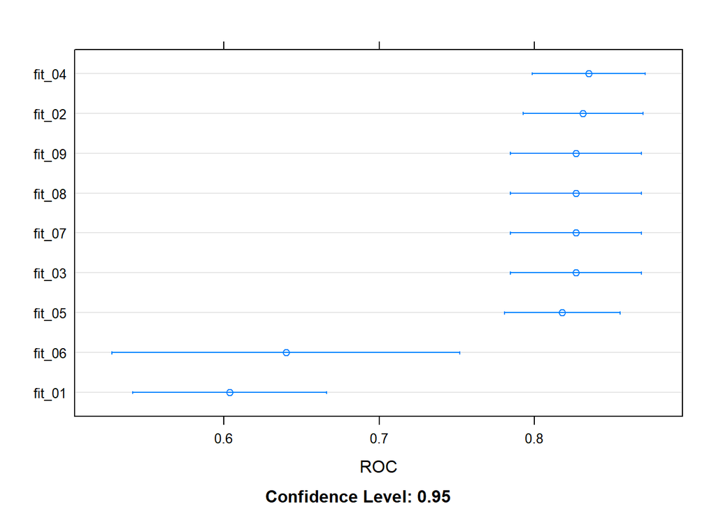

```r
dotplot(results, metric = "ROC")
```

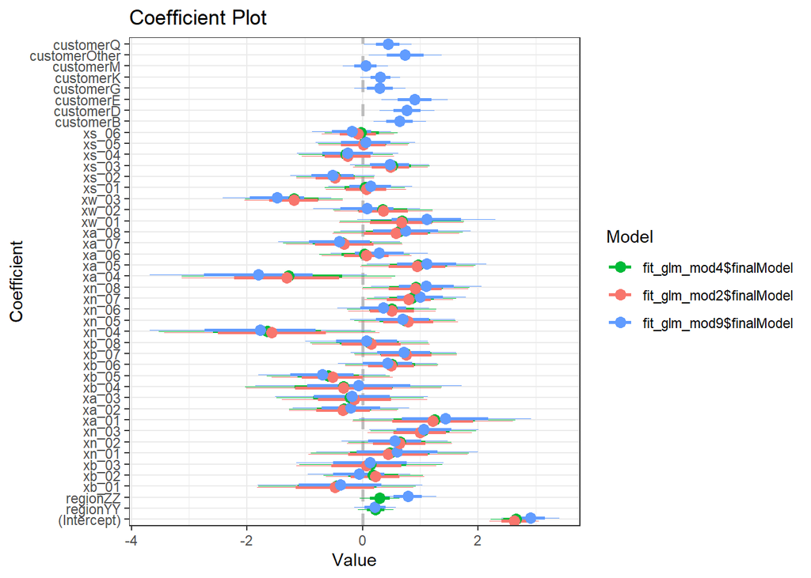

```r
coefplot::multiplot(fit_glm_mod4$finalModel, fit_glm_mod2$finalModel, fit_glm_mod9$finalModel,
                    dodgeHeight = 0.35) +
  theme_bw()
```

```r
dfiiiA <- df_all %>%
  mutate(y = ifelse(outcome == 'event', 1, 0)) %>%
  select(region, customer, starts_with('x'), y)

Xmat_01 <- model.matrix(y~. , data = dfiiiA )

info_01 <- list(
  yobs = dfiiiA$y,
  design_matrix = Xmat_01,
  mu_beta = 0,
  tau_beta = 5,
  sigma_rate = 1
)

dfiiiA <- df_all %>%
  mutate(y = ifelse(outcome == 'event', 1, 0)) %>%
  select(starts_with('x'), y)

Xmat_02 <- model.matrix(y ~ ., data = dfiiiA)

info_02 <- list(
  yobs = dfiiiA$y,
  design_matrix = Xmat_02,
  mu_beta = 0,
  tau_beta = 5,
  sigma_rate = 1
)
```

```r
lm_logpost <- function(unknowns, my_info)
{
  # specify the number of unknown beta parameters
  length_beta <- ncol(my_info$design_matrix)

  # extract the beta parameters from the `unknowns` vector
  beta_v <- unknowns[1:length_beta]

  # extract the unbounded noise parameter, varphi
  lik_varphi <- unknowns[length_beta + 1]

  # back-transform from varphi to sigma
  lik_sigma <- exp(lik_varphi)

  # extract design matrix
  X <- my_info$design_matrix

  # calculate the linear predictor
  mu <- as.vector(X %*% as.matrix(beta_v))

  # evaluate the log-likelihood
  log_lik <- sum(dnorm(x = my_info$yobs,
                       mean = mu,
                       sd = lik_sigma,
                       log = TRUE))

  # evaluate the log-prior
  log_prior_beta <- sum(dnorm(x = beta_v,
                              mean = my_info$mu_beta,
                              sd = my_info$tau_beta,
                              log = TRUE))

  log_prior_sigma <- dexp(x = lik_sigma,
                          rate = my_info$sigma_rate,
                          log = TRUE)

  # add the mean trend prior and noise prior together
  log_prior <- log_prior_beta + log_prior_sigma

  # account for the transformation
  log_derive_adjust <- lik_varphi

  # sum together
  log_lik + log_prior + log_derive_adjust
}
```

You may use the Laplace Approximation approach we used in lecture and the homework assignments.

```r
my_laplace <- function(start_guess, logpost_func, ...)
{
  # code adapted from the `LearnBayes`` function `laplace()`
  fit <- optim(start_guess,
               logpost_func,
               gr = NULL,
               ...,
               method = "BFGS",
               hessian = TRUE,
               control = list(fnscale = -1, maxit = 1001))

  mode <- fit$par
  post_var_matrix <- -solve(fit$hessian)
  p <- length(mode)
  int <- p/2 * log(2 * pi) + 0.5 * log(det(post_var_matrix)) + logpost_func(mode, ...)
  # package all of the results into a list
  list(mode = mode,
       var_matrix = post_var_matrix,
       log_evidence = int,
       converge = ifelse(fit$convergence == 0,
                         "YES",
                         "NO"),
       iter_counts = as.numeric(fit$counts[1]))
}
```

• Fit 2 Bayesian linear models – one must be the best model from iiA) and the second must be another model you fit in iiA).

```r
laplace_01 <- my_laplace(rep(
  0, ncol(Xmat_01)+1), lm_logpost, info_01)
```

```r
laplace_02 <- my_laplace(rep(0, ncol(Xmat_02)+1), lm_logpost, info_02)
```

```r
laplace_01$mode
```

```
##  [1]  4.221752e-01 -5.194873e-02 -1.513707e-01 -2.200077e-01 -2.503471e-01
##  [6] -2.874933e-01 -4.043138e-02 -1.245272e-01 -1.333348e-02 -1.186268e-01
## [11] -1.184497e-01  8.526318e-03  2.556688e-03 -9.799725e-03  3.074515e-02
## [16] -3.389581e-02 -4.230076e-02 -2.752622e-02  2.531022e-03  1.502823e-02
## [21] -2.202886e-02  6.451156e-02 -1.786425e-02 -5.688251e-02  2.096239e-03
## [26]  6.159671e-02 -7.191328e-02 -3.566793e-02 -3.622111e-02 -2.812802e-02
## [31]  4.760757e-02 -4.944940e-02 -2.847576e-03  3.796775e-02 -1.257248e-02
## [36] -6.064167e-03  1.480257e-03  4.912727e-03  3.349854e-05  1.792768e-01
## [41] -1.805534e-01  1.013438e-01 -3.054421e-02  1.193768e-01 -1.100681e+00
```

```r
laplace_02$mode
```

```
##  [1]  0.2303284256  0.0159154713 -0.0053458962 -0.0105674015  0.0296546514
##  [6] -0.0347076023 -0.0409257562 -0.0280461881  0.0035999164  0.0153081367
## [11]  0.0021445026  0.0556685423 -0.0230313117 -0.0645836045 -0.0011591834
## [16]  0.0565179156 -0.0856346215 -0.0438334965 -0.0247027319 -0.0190403891
## [21]  0.0435922007 -0.0492185949  0.0001393672  0.0380995971 -0.0133284119
## [26] -0.0046450805  0.0006790368  0.0045950733  0.0243323230  0.2213379725
## [31] -0.2196536332  0.0949398157 -0.0280208027  0.1138589940 -1.0852991598
```

```r
sqrt(diag(laplace_01$var_matrix))
```

```
##  [1] 0.102253597 0.038751005 0.050808795 0.083397782 0.090580826 0.091563873
##  [7] 0.056840379 0.073068217 0.060735086 0.065227108 0.090453413 0.036341257
## [13] 0.015380483 0.023033928 0.034569492 0.016011275 0.019588551 0.018302063
## [19] 0.007425570 0.011746393 0.118515188 0.055521263 0.029331718 0.045791769
## [25] 0.047783465 0.105116896 0.045151099 0.028656911 0.043193950 0.040643704
## [31] 0.057738149 0.023725085 0.011771430 0.025753945 0.025888041 0.003088672
## [37] 0.001600571 0.001766504 0.261498694 0.146922128 0.118827179 0.401791586
## [43] 0.284655857 0.158346896 0.027186271
```

```r
sqrt(diag(laplace_02$var_matrix))
```

```
##  [1] 0.075772211 0.036392468 0.015273442 0.023072005 0.034671481 0.016088439
##  [7] 0.019640426 0.018425288 0.007483725 0.011835761 0.118363010 0.055518712
## [13] 0.029582396 0.046005357 0.048057671 0.105888483 0.045306941 0.028789867
## [19] 0.043307221 0.041074164 0.057959701 0.023976817 0.011867580 0.025705755
## [25] 0.026090236 0.003014708 0.001575647 0.001737268 0.264845980 0.148118125
## [31] 0.119688523 0.403065300 0.286453236 0.158444744 0.027186132
```

```r
generate_lm_post_samples <- function(mvn_result, length_beta, num_samples)
{
  MASS::mvrnorm(n = num_samples,
                mu = mvn_result$mode,
                Sigma = mvn_result$var_matrix) %>%
    as.data.frame() %>% tibble::as_tibble() %>%
    purrr::set_names(c(sprintf("beta_%02d", 0:(length_beta-1)), "varphi")) %>%
    mutate(sigma = exp(varphi))
}
```

```r
set.seed(87123)
post_samples_01 <- generate_lm_post_samples(laplace_01, ncol(Xmat_01), 2500)
```

```r
set.seed(87123)
post_samples_02 <- generate_lm_post_samples(laplace_02, ncol(Xmat_02), 2500)
```

```r
post_lm_pred_samples <- function(Xnew, Bmat, sigma_vector)
{
  # number of new prediction locations
  M <- nrow(Xnew)
  # number of posterior samples
  S <- nrow(Bmat)

  # matrix of linear predictors
  Umat <- Xnew %*% t(Bmat)

  # assmeble matrix of sigma samples
  Rmat <- matrix(rep(sigma_vector, M), M, byrow = TRUE)

  # generate standard normal and assemble into matrix
  Zmat <- matrix(rnorm(M*S), M, byrow = TRUE)

  # calculate the random observation predictions
  Ymat <- Umat + Rmat * Zmat

  # package together
  list(Umat = Umat, Ymat = Ymat)
}
```

```r
make_post_lm_pred <- function(Xnew, post)
{
  Bmat <- post %>% select(starts_with("beta_")) %>% as.matrix()

  sigma_vector <- post %>% pull(sigma)

  post_lm_pred_samples(Xnew, Bmat, sigma_vector)
}
```

```r
post_pred_samples_01 <- make_post_lm_pred(Xmat_01, post_samples_01)
```

```r
post_pred_samples_02 <- make_post_lm_pred(Xmat_02, post_samples_02)
```

```r
### error of the first posterior sample
error_01_post_01 <- post_pred_samples_01$Umat[, 1] - dfiiiA$y

### error of the second posterior sample
error_01_post_02 <- post_pred_samples_01$Umat[, 2] - dfiiiA$y

### error of the third posterior sample
error_01_post_03 <- post_pred_samples_01$Umat[, 3] - dfiiiA$y
```

```r
### error of the first posterior sample
error_02_post_01 <- post_pred_samples_02$Umat[, 1] - dfiiiA$y

### error of the second posterior sample
error_02_post_02 <- post_pred_samples_02$Umat[, 2] - dfiiiA$y

### error of the third posterior sample
error_02_post_03 <- post_pred_samples_02$Umat[, 3] - dfiiiA$y
```

```r
mae_01_post_01 <- mean(abs(error_01_post_01))

mae_01_post_02 <- mean(abs(error_01_post_02))

mae_01_post_03 <- mean(abs(error_01_post_03))
```

```r
mae_02_post_01 <- mean(abs(error_02_post_01))

mae_02_post_02 <- mean(abs(error_02_post_02))

mae_02_post_03 <- mean(abs(error_02_post_03))
```

For your best model: Study the posterior uncertainty in the noise (residual error),

```r
signif(c(mae_01_post_01,mae_01_post_02,mae_01_post_03), 6)
```

```
## [1] 0.262381 0.266884 0.272342
```

```r
signif(c(mae_02_post_01 ,mae_02_post_02,mae_02_post_03 ), 6)
```

```
## [1] 0.275814 0.272108 0.261466
```

• Visualize the regression coefficient posterior summary statistics for your best model.

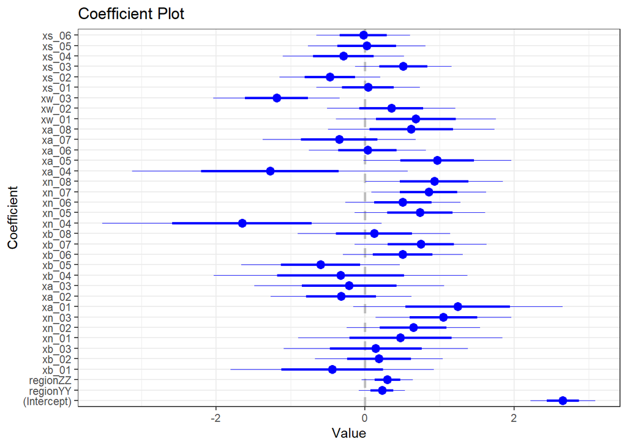

```r
coefplot::coefplot(fit_glm_mod4$finalModel,
                    dodgeHeight = 0.35) +
  theme_bw()
```

• You must make predictions with your 2 selected linear models in order to visualize the trends of the logtransformed response with respect to the inputs.

```r
fit_glm_mod4%>% summary()
```

```
##
## Call:
## NULL
##
## Deviance Residuals:
##      Min        1Q    Median        3Q       Max
## -2.59618   0.04073   0.25755   0.54442   2.36368
##
## Coefficients:
##             Estimate Std. Error z value Pr(>|z|)
## (Intercept)  2.65419    0.21800  12.175  < 2e-16 ***
## regionYY     0.22644    0.15398   1.471  0.14141
## regionZZ     0.29873    0.17311   1.726  0.08441 .
## xb_01       -0.44135    0.68312  -0.646  0.51823
## xb_02        0.18599    0.42953   0.433  0.66501
## xb_03        0.14367    0.61709   0.233  0.81590
## xn_01        0.47372    0.68477   0.692  0.48906
## xn_02        0.64660    0.44832   1.442  0.14922
## xn_03        1.05187    0.45687   2.302  0.02132 *
## xa_01        1.24321    0.70280   1.769  0.07691 .
## xa_02       -0.32210    0.47252  -0.682  0.49545
## xa_03       -0.21322    0.63779  -0.334  0.73814
## xb_04       -0.32870    0.85130  -0.386  0.69941
## xb_05       -0.59591    0.53268  -1.119  0.26327
## xb_06        0.50533    0.40224   1.256  0.20902
## xb_07        0.74615    0.44361   1.682  0.09257 .
## xb_08        0.12029    0.51181   0.235  0.81419
## xn_04       -1.65092    0.93717  -1.762  0.07814 .
## xn_05        0.73598    0.43699   1.684  0.09214 .
## xn_06        0.50608    0.38590   1.311  0.18972
## xn_07        0.85169    0.38505   2.212  0.02698 *
## xn_08        0.92790    0.46101   2.013  0.04414 *
## xa_04       -1.27626    0.92423  -1.381  0.16731
## xa_05        0.96986    0.49525   1.958  0.05019 .
## xa_06        0.03269    0.39226   0.083  0.93358
## xa_07       -0.34834    0.51319  -0.679  0.49728
## xa_08        0.61902    0.55955   1.106  0.26860
## xw_01        0.68090    0.53649   1.269  0.20438
## xw_02        0.35123    0.42953   0.818  0.41353
## xw_03       -1.18751    0.42385  -2.802  0.00508 **
## xs_01        0.04069    0.34763   0.117  0.90682
## xs_02       -0.47274    0.33762  -1.400  0.16145
## xs_03        0.51216    0.32341   1.584  0.11328
## xs_04       -0.29118    0.40682  -0.716  0.47414
## xs_05        0.02128    0.39376   0.054  0.95691
## xs_06       -0.02487    0.31542  -0.079  0.93714
## ---
## Signif. codes:  0 '***' 0.001 '**' 0.01 '*' 0.05 '.' 0.1 ' ' 1
##
## (Dispersion parameter for binomial family taken to be 1)
##
##     Null deviance: 653.59  on 676  degrees of freedom
## Residual deviance: 424.94  on 641  degrees of freedom
## AIC: 496.94
##
## Number of Fisher Scoring iterations: 7
```

```r
fit_glm_mod2%>% summary()
```

```
##
## Call:
## NULL
##
## Deviance Residuals:
##      Min        1Q    Median        3Q       Max
## -2.53568   0.04411   0.25432   0.54178   2.29122
##
## Coefficients:
##             Estimate Std. Error z value Pr(>|z|)
## (Intercept)  2.62538    0.21474  12.226  < 2e-16 ***
## xb_01       -0.47493    0.67569  -0.703  0.48213
## xb_02        0.21851    0.42771   0.511  0.60943
## xb_03        0.07027    0.60613   0.116  0.90770
## xn_01        0.44156    0.68867   0.641  0.52140
## xn_02        0.63617    0.45418   1.401  0.16130
## xn_03        0.99115    0.45210   2.192  0.02835 *
## xa_01        1.21548    0.69599   1.746  0.08074 .
## xa_02       -0.33698    0.46626  -0.723  0.46984
## xa_03       -0.13977    0.63009  -0.222  0.82445
## xb_04       -0.32527    0.84099  -0.387  0.69892
## xb_05       -0.52202    0.52513  -0.994  0.32018
## xb_06        0.49834    0.39824   1.251  0.21080
## xb_07        0.75457    0.44191   1.708  0.08773 .
## xb_08        0.14984    0.50915   0.294  0.76853
## xn_04       -1.57065    0.93299  -1.683  0.09229 .
## xn_05        0.79235    0.42973   1.844  0.06521 .
## xn_06        0.50951    0.37963   1.342  0.17955
## xn_07        0.80284    0.38272   2.098  0.03593 *
## xn_08        0.91301    0.45953   1.987  0.04694 *
## xa_04       -1.30789    0.90888  -1.439  0.15015
## xa_05        0.94710    0.49024   1.932  0.05337 .
## xa_06        0.06809    0.38927   0.175  0.86114
## xa_07       -0.31474    0.50591  -0.622  0.53385
## xa_08        0.57873    0.54951   1.053  0.29227
## xw_01        0.66889    0.53716   1.245  0.21304
## xw_02        0.36068    0.42607   0.847  0.39725
## xw_03       -1.19175    0.42539  -2.802  0.00509 **
## xs_01        0.06266    0.34685   0.181  0.85664
## xs_02       -0.47222    0.33880  -1.394  0.16337
## xs_03        0.48432    0.32316   1.499  0.13395
## xs_04       -0.25508    0.39872  -0.640  0.52234
## xs_05        0.01283    0.38674   0.033  0.97353
## xs_06       -0.07865    0.31263  -0.252  0.80138
## ---
## Signif. codes:  0 '***' 0.001 '**' 0.01 '*' 0.05 '.' 0.1 ' ' 1
##
## (Dispersion parameter for binomial family taken to be 1)
##
##     Null deviance: 653.59  on 676  degrees of freedom
## Residual deviance: 428.46  on 643  degrees of freedom
## AIC: 496.46
##
## Number of Fisher Scoring iterations: 7
```

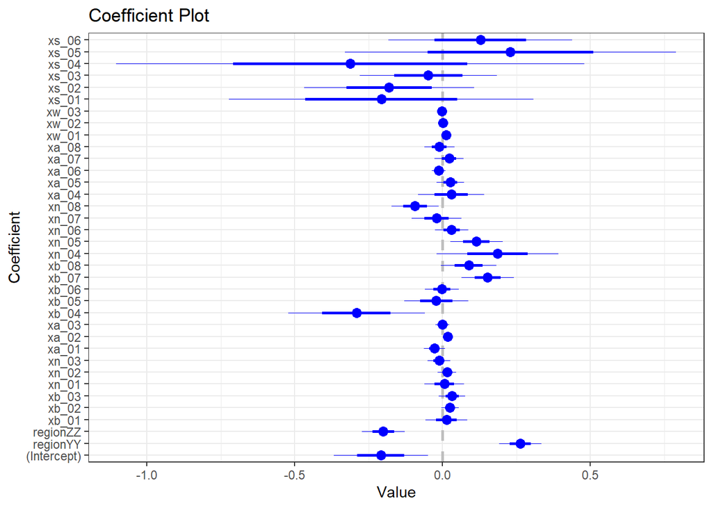

```r
set.seed(2001)
dfii <- df_all %>%
  mutate(y = log(response)) %>%
  select(region, starts_with('x'), y)
fit_glm_mod4<- lm( y ~ ., data = dfii )
fit_glm_mod4 %>% coefplot::coefplot() +
  theme_bw()
```

```r
tidy_predict <- function(mod, xnew)
{
  pred_df <- predict(mod, xnew, interval = "confidence") %>%
    as.data.frame() %>% tibble::as_tibble() %>%
    dplyr::select(pred = fit, ci_lwr = lwr, ci_upr = upr) %>%
    bind_cols(predict(mod, xnew, interval = 'prediction') %>%
                as.data.frame() %>% tibble::as_tibble() %>%
                dplyr::select(pred_lwr = lwr, pred_upr = upr))

  xnew %>% bind_cols(pred_df)
}
```

```r
viz_grid_best <- expand.grid(xn_03 =seq(1,10,length.out=101) ,
                        xn_07=seq(30,75,length.out=9),
                        region=c('YY','ZZ'),
                        xb_01=c(0),xb_02=c(0),xb_03=c(0),xb_04=c(0),xb_05=c(0),xb_06=c(0),xb_07=c(0),xb_08=c(0),
                        xn_01=c(0),xn_02=c(0),xn_04=c(0),xn_05=c(0),xn_06=c(0),xn_08=c(0),
                        xa_01=c(0),xa_02=c(0),xa_03=c(0),xa_04=c(0),xa_05=c(0),xa_06=c(0),xa_07=c(0),xa_08=c(0),
                        xw_01=c(0),xw_02=c(0),xw_03=c(0),
                        xs_01=c(0),xs_02=c(0),xs_03=c(0),xs_04=c(0),xs_05=c(0),xs_06=c(0),
                        KEEP.OUT.ATTRS = TRUE,
                        stringsAsFactors = TRUE) %>%
  as.data.frame() %>% tibble::as_tibble()
```

```r
pred_glm_4 <- tidy_predict(fit_glm_mod4,viz_grid_best)
```

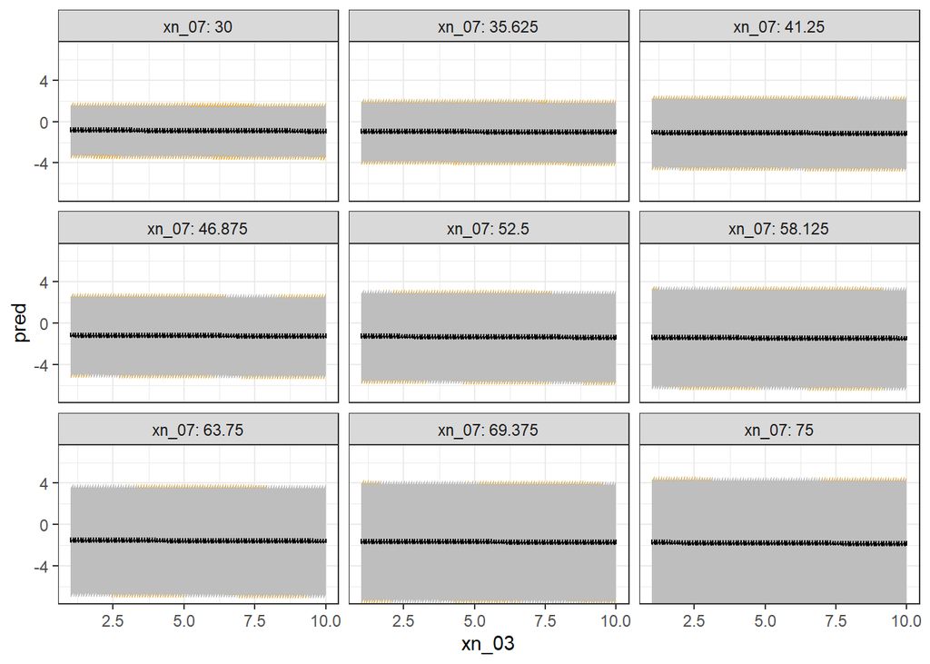

```r
pred_glm_4 %>%
  ggplot(mapping = aes(x = xn_03)) +
  geom_ribbon(mapping = aes(ymin = pred_lwr, ymax = pred_upr),
              fill = 'orange') +
  geom_ribbon(mapping = aes(ymin = ci_lwr, ymax = ci_upr),
              fill = 'grey') +
  geom_line(mapping = aes(y = pred),
            color = 'black') +
  coord_cartesian(ylim = c(-7, 7)) +
  facet_wrap(~xn_07, labeller = "label_both") +
  theme_bw()
```

For categorical inputs, we set region to be ‘YY’, and customer to be’0’. For continuous inputs, we set them all equal to 0.

```r
viz_grid_best2 <- expand.grid(xn_03 =seq(1,10,length.out=101) ,
                        xn_08=seq(30,75,length.out=9),
                        region=c('YY'),
                        xb_01=c(0),xb_02=c(0),xb_03=c(0),xb_04=c(0),xb_05=c(0),xb_06=c(0),xb_07=c(0),xb_08=c(0),
                        xn_01=c(0),xn_02=c(0),xn_04=c(0),xn_05=c(0),xn_06=c(0),xn_07=c(0),
                        xa_01=c(0),xa_02=c(0),xa_03=c(0),xa_04=c(0),xa_05=c(0),xa_06=c(0),xa_07=c(0),xa_08=c(0),
                        xw_01=c(0),xw_02=c(0),xw_03=c(0),
                        xs_01=c(0),xs_02=c(0),xs_03=c(0),xs_04=c(0),xs_05=c(0),xs_06=c(0),
                        KEEP.OUT.ATTRS = TRUE,
                        stringsAsFactors = TRUE) %>%
  as.data.frame() %>% tibble::as_tibble()
```

```r
pred_lm_best2<-tidy_predict(fit_glm_mod4,viz_grid_best2)
```

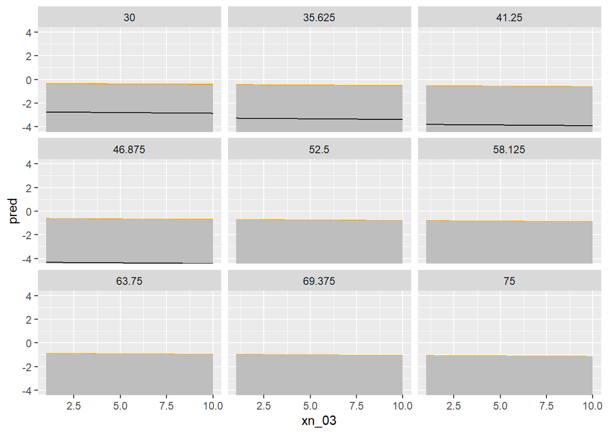

```r
pred_lm_best2 %>%
  ggplot(mapping=aes(x=xn_03))+
  geom_ribbon(mapping=aes(ymin=pred_lwr,ymax=pred_upr),fill='orange')+
  geom_ribbon(mapping=aes(ymin=ci_lwr,ymax=ci_upr),fill='grey')+
  geom_line(mapping=aes(y=pred))+
  coord_cartesian(ylim=c(-4,4))+
  facet_wrap(~xn_08)
```

```r
viz_grid_best3 <- expand.grid(xn_03 =seq(1,10,length.out=101) ,
                        xw_03=seq(30,75,length.out=9),
                        region=c('YY'),
                        xb_01=c(0),xb_02=c(0),xb_03=c(0),xb_04=c(0),xb_05=c(0),xb_06=c(0),xb_07=c(0),xb_08=c(0),
                        xn_01=c(0),xn_02=c(0),xn_04=c(0),xn_05=c(0),xn_06=c(0),xn_07=c(0),xn_08=c(0),
                        xa_01=c(0),xa_02=c(0),xa_03=c(0),xa_04=c(0),xa_05=c(0),xa_06=c(0),xa_07=c(0),xa_08=c(0),
                        xw_01=c(0),xw_02=c(0),
                        xs_01=c(0),xs_02=c(0),xs_03=c(0),xs_04=c(0),xs_05=c(0),xs_06=c(0),
                        KEEP.OUT.ATTRS = TRUE,
                        stringsAsFactors = TRUE) %>%
  as.data.frame() %>% tibble::as_tibble()
```

```r
pred_lm_best3<-tidy_predict(fit_glm_mod4,viz_grid_best3)
```

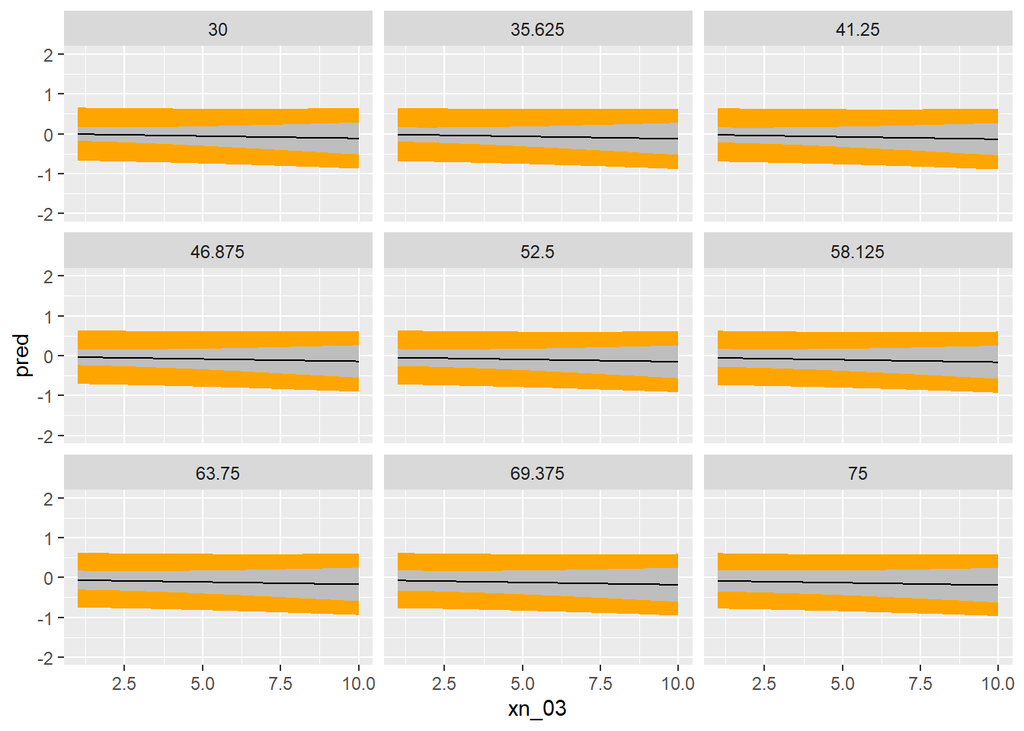

```r
pred_lm_best3 %>%
  ggplot(mapping=aes(x=xn_03))+
  geom_ribbon(mapping=aes(ymin=pred_lwr,ymax=pred_upr),fill='orange')+
  geom_ribbon(mapping=aes(ymin=ci_lwr,ymax=ci_upr),fill='grey')+
  geom_line(mapping=aes(y=pred))+
  coord_cartesian(ylim=c(-2,2))+
  facet_wrap(~xw_03)
```

## PART III-D

Regularized regression with Elastic net

```r
set.seed(2001)
dfiiiD <- df_all %>%
  mutate(outcome = factor(outcome,
                          levels = c("event", "non_event"))) %>%
  select(region,  starts_with('x'),outcome)

ctrl_roc <- trainControl(method ='cv', number = 5,
                             summaryFunction = twoClassSummary,
                             classProbs = TRUE,
                             savePredictions = TRUE)

fit_glmnet_mod4 <- train(outcome ~ xn_03+xn_07+xn_08+xw_03, data = dfiiiD,
                        method = 'glmnet',
                        metric = "ROC",
                        preProcess = c("center", "scale"),
                        trControl = ctrl_roc)
```

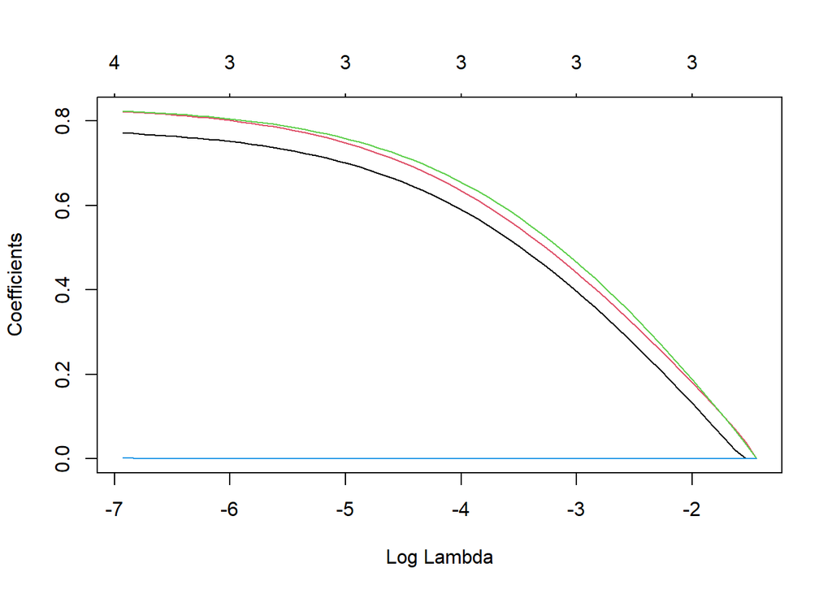

```r
plot( fit_glmnet_mod4$finalModel, xvar = 'lambda' )
```

Neural network

```r
set.seed(2001)
dfiiiD <- df_all %>%
  mutate(outcome = factor(outcome,
                          levels = c("event", "non_event"))) %>%
  select(region,  starts_with('x'),outcome)

ctrl_roc <- trainControl(method ='cv', number = 5,
                             summaryFunction = twoClassSummary,
                             classProbs = TRUE,
                             savePredictions = TRUE)

fit_nnet_mod4 <- train( outcome ~ xn_03+xn_07+xn_08+xw_03, data = dfiiiD,
                        method = 'nnet',
                        metric = "ROC",
                        preProcess = c("center", "scale"),
                        trControl = ctrl_roc)
```

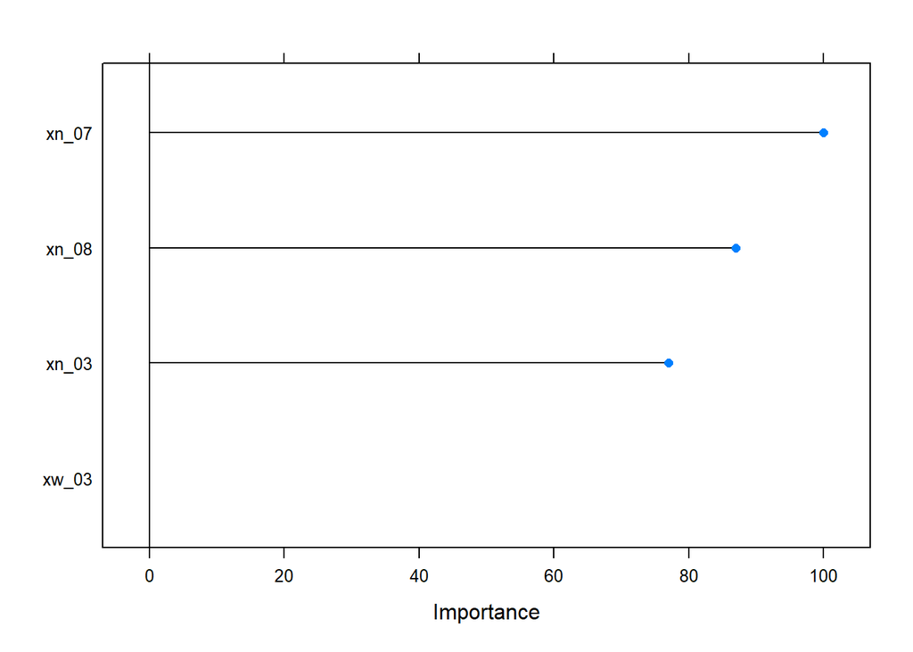

```r
plot(varImp(fit_nnet_mod4))
```

Random forest

```r
set.seed(2001)
dfiiiD <- df_all %>%
  mutate(outcome = factor(outcome,
                          levels = c("event", "non_event"))) %>%
  select(region,  starts_with('x'),outcome)

ctrl_roc <- trainControl(method ='cv', number = 5,
                             summaryFunction = twoClassSummary,
                             classProbs = TRUE,
                             savePredictions = TRUE)

fit_rf_mod4 <- train( outcome ~ xn_03+xn_07+xn_08+xw_03, data = dfiiiD,
                        method = 'rf',
                        metric = "ROC",
                        preProcess = c("center", "scale"),
                        trControl = ctrl_roc)
```

Gradient boosted tree

```r
set.seed(2001)
dfiiiD <- df_all %>%
  mutate(outcome = factor(outcome,
                          levels = c("event", "non_event"))) %>%
  select(region,  starts_with('x'),outcome)

ctrl_roc <- trainControl(method ='cv', number = 5,
                             summaryFunction = twoClassSummary,
                             classProbs = TRUE,
                             savePredictions = TRUE)

fit_xgb_mod4 <- train( outcome ~ xn_03+xn_07+xn_08+xw_03, data = dfiiiD,
                        method = 'xgbTree',
                        metric = "ROC",
                        preProcess = c("center", "scale"),
                        trControl = ctrl_roc)
```

[output not shown]

[output cut: 665 more lines]

[output not shown]

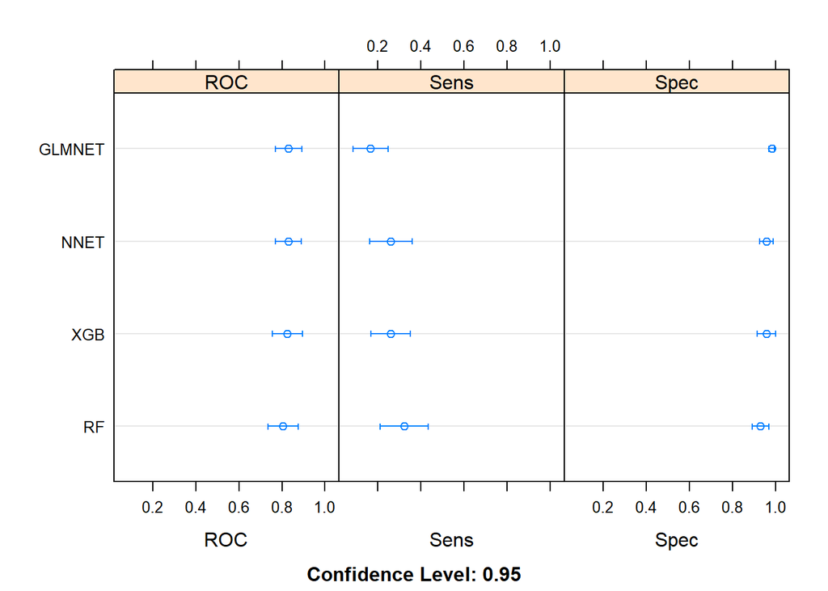

```r
dfii_roc_compare <- resamples(list( GLMNET = fit_glmnet_mod4,
                                    NNET = fit_nnet_mod4,
                                    RF = fit_rf_mod4,
                                    XGB = fit_xgb_mod4))

dotplot(dfii_roc_compare)
```

According to ROC and spec,performance of each model is close.However,it seems like GLMNET has the lowest sens which means we are able to make smaller and precise movements.